# COVID19-Singapore

O.V.Kulasekara

AS2019420

## Intoduction

• Background

Singapore is a sunny, tropical island in South-east Asia. The city-state is 710 square kilometers and inhabited by five million people from four major communities: Chinese (majority), Malay, Indian and Eurasian. Singapore is today (beside Monaco) the most densely populated independent country in the world. Its strategic location at the Strait of Malacca and the South China Sea, combined with a mostly corruption-free government, a skilled workforce, pro-foreign investment and export-oriented, led to a thriving free-market economy that attracts international investment funds on a large scale despite its relatively high-cost operating environment. Singapore is a parliamentary representative democratic republic with a (in theory) multi-party system. Singapore is one of the most market-oriented and open economies in the world and is also considered the easiest country in which to do business. Singapore is a major international maritime center and a global air hub. The Port of Singapore is the world’s second-busiest port in terms of total shipping tonnage.

• COVID19 in Singapore

The COVID-19 pandemic in Singapore is part of the worldwide pandemic of coronavirus disease 2019 (COVID-19) caused by severe acute respiratory syndrome coronavirus 2 (SARS-CoV-2). The first case in Singapore was confirmed on 23 January 2020. Early cases were primarily imported until local transmission began to develop in February and March. In late March and April, COVID-19 clusters were detected at multiple migrant worker dormitories, which soon contributed to an overwhelming proportion of new cases in the country. To stem the tide of infections, strict circuit breaker lockdown measures were implemented from 7 April to 1 June 2020, after which restrictions have been gradually lifted as conditions permitted.

A mass vaccination program is currently under way following the approval and acquisition of the Pfizer–BioNTech and Moderna COVID-19 vaccines. In late 2021, Singapore became the world’s most-vaccinated country, with more than 85% of its total population fully vaccinated. As of June 2022, over 92% of the total population have completed their vaccination regimen, representing over 96% of the eligible populace.

Various measures have been taken to mass test the population for the virus and isolate infected people. Contact tracing measures SafeEntry and TraceTogether were implemented to identify and quarantine close contacts of positive cases.

The country currently has a case fatality rate of 0.08%, one of the lowest in the world. It introduced what was considered one of the world’s largest and best-organized epidemic control programs.

[interactive chart not shown]

**Figure 01 - Visualization of the location on world map**

**Explanatory Data Analysis**

**Structure of the data**

Qualitative Data -

• date: Date in YYYY-MM-DD format.

• province: Name of province/state, for countries where data is provided split across multiple provinces/states.

• country: Name of country/region.

• type: An indicator for the type of cases (confirmed, death, recovered).

Quantitative Data –

• cases: Number of cases on given date.

• long: Longitude of center of geographic region, defined as either country or, if available, province.

• lat: Latitude of center of geographic region, defined as either country or, if available, province.

**Summary Measures**

| type | Minimum | First_Quantile | Median | Mean | Third_Quantile | Maximum | Total |
| --- | --- | --- | --- | --- | --- | --- | --- |
| confirmed | 0 | 15 | 94.5 | 1573.02941 | 1101.5 | 39252 | 1390558 |
| death | 0 | 0 | 0.0 | 1.59276 | 1.0 | 22 | 1408 |
| recovery | 0 | 0 | 8.0 | 72.21315 | 28.0 | 1337 | 63692 |

```
      date              province           country               lat
 Min.   :2020-01-22   Length:2650        Length:2650        Min.   :1.283
 1st Qu.:2020-08-29   Class :character   Class :character   1st Qu.:1.283
 Median :2021-04-07   Mode  :character   Mode  :character   Median :1.283
 Mean   :2021-04-07                                         Mean   :1.283
 3rd Qu.:2021-11-14                                         3rd Qu.:1.283
 Max.   :2022-06-23                                         Max.   :1.283
      long           type               cases               uid
 Min.   :103.8   Length:2650        Min.   :    0.00   Min.   :702
 1st Qu.:103.8   Class :character   1st Qu.:    0.00   1st Qu.:702
 Median :103.8   Mode  :character   Median :    7.00   Median :702
 Mean   :103.8                      Mean   :  549.30   Mean   :702
 3rd Qu.:103.8                      3rd Qu.:   42.75   3rd Qu.:702
 Max.   :103.8                      Max.   :39252.00   Max.   :702
     iso2               iso3               code3     combined_key
 Length:2650        Length:2650        Min.   :702   Length:2650
 Class :character   Class :character   1st Qu.:702   Class :character
 Mode  :character   Mode  :character   Median :702   Mode  :character
                                       Mean   :702
                                       3rd Qu.:702
                                       Max.   :702
   population      continent_name     continent_code
 Min.   :5850343   Length:2650        Length:2650
 1st Qu.:5850343   Class :character   Class :character
 Median :5850343   Mode  :character   Mode  :character
 Mean   :5850343
 3rd Qu.:5850343
 Max.   :5850343
```

**Table 01 - Summary measures of total number of confirmed, death and recovery cases.**

**Visualization of data**

[figure not shown]

**Figure 02 - Daily confirmed,death,recovery cases**

The above multiple time series plot shows that how cases have changed over time. According the animated representation, confirmed cases increasing compare to the death and recovered cases over time.

Total Number of Confirmed, Death and Recovered Cases in Singapore

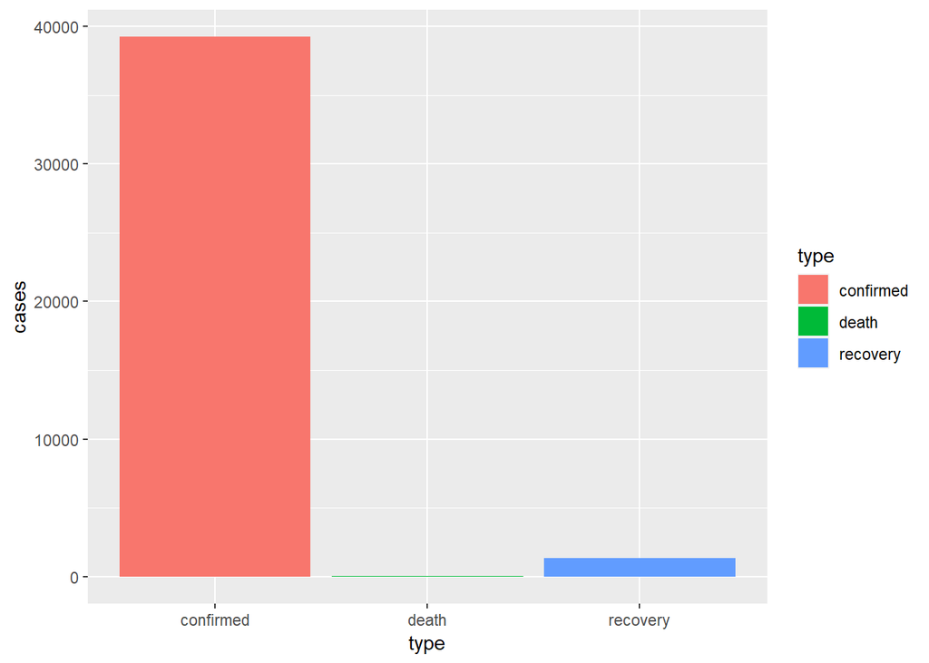

Overall Singapore has been performing well in keeping the fatality rate very low compare to the confirmed cases.This figure shows that the total number of death cases are negligibly small compare to the confirmed and recovery cases.

[figure not shown]

**Figure 04 - Daily Active Cases**

Above animated figure represents the daily active cases in Singapore. Daily active cases growth rate in Singapore appears a higher growth rate in 2020 and shows a considerable drop after 2020.

**Comparison with other countries**

Here I compare the cases of Singapore with several other countries. Compare the situation with the bordering countries like Malaysia and Indonesia is an important factor when considering its relationships, national security, access to resources and more. And compare data with the most focused countries in Asia during the corona period like China and India are also important. Further I compare Singapore COVID19 cases with our country.

[interactive chart not shown]

**Figure 05 - locations in other countries on world map**

[figure not shown]

**Figure 06 - Multiple Time Series plot**

The above Multiple Time series plot clearly shows that Indonesia has the highest number of confirmed corona cases compare to the other two countries over the time. According to the above plot Singapore considerably increases the number of confirmed cases after end period of 2021.

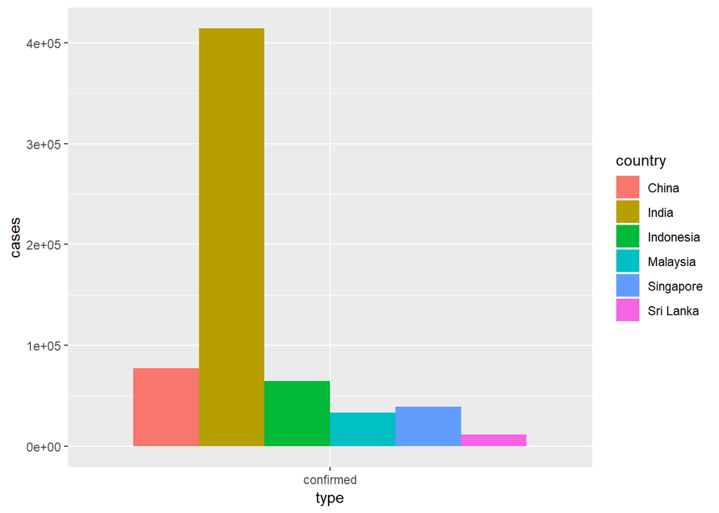

According to the above figure total number of COVID19 cases are lower in Singapore compare to the other most leading countries but it is higher than compare to Malaysia and Sri Lanka.This figure shows that confirmed cases in India is more than the other countries combined cases.

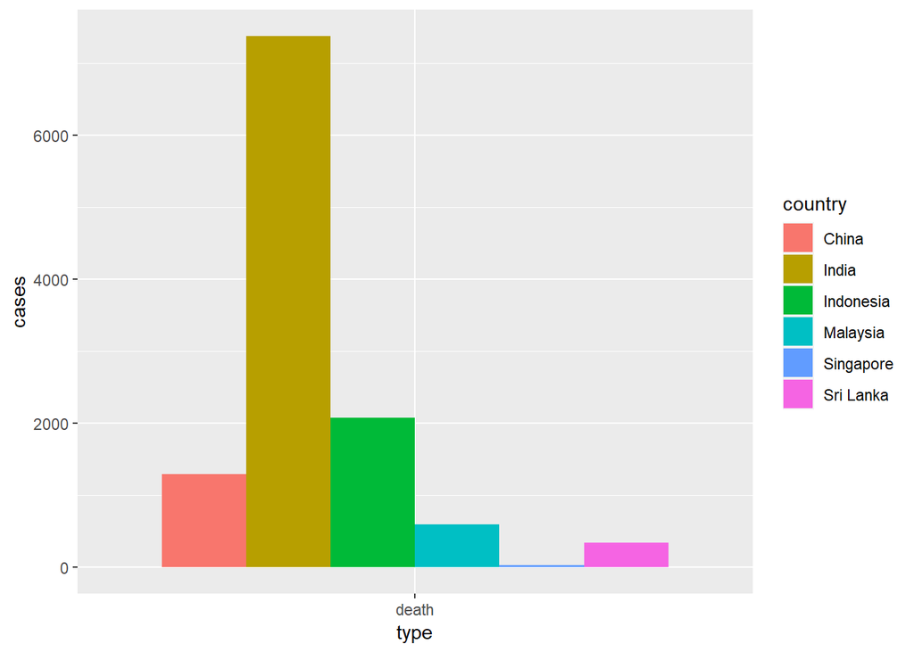

**Figure 08 - Total number of death cases by country**

Above figure shows that the total number of death cases in Singapore is negligibly small compare to the other countries.The highest number of death cases are also reported in India.

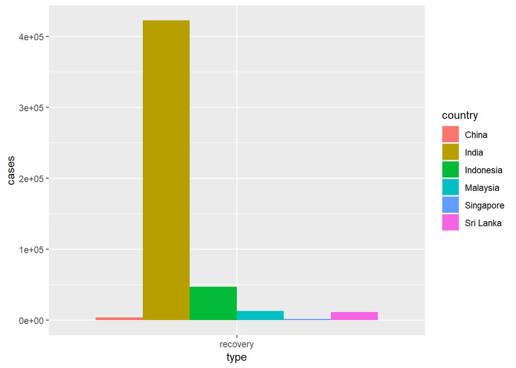

**Figure 09 - Total number of recovery cases by country**

This figure shows that the highest number of recovery cases are reported in India and the lowest number of recovery cases are reported in Singapore and China.

Limitation - In analysis with other countries, I have ignored NA cases and negative value cases.

**Conclusions and Discussion**

We are still facing the global crisis of the COVID19 pandemic and it is an ongoing global pandemic caused by severe acute respiratory syndrome corona virus. Coronavirus disease2019 is identified in December 2019 in Wuhan, Hubei but It is increased speedily in January to March in 2020. The outbreak of the COVID-19 pandemic has led to profound health shocks worldwide, resulting in more than 2.4 million deaths. To contain the virus in the absence of effective drugs and vaccines, many governments have implemented a wide variety of non-pharmaceutical interventions (NPIs) at an unprecedented scale. Citizens have also been following risk avoidance behaviors such as wearing facial masks and staying at home, even before governments imposed strict social distancing rules. Because of that even if the most of countries had high risk but same controlled the situation.

**Reference**

https://hellor.netlify.app/ https://www.mfa.gov.sg/Overseas-Mission/Xiamen/About- Singapore#:~:text=Singapore%20is%20a%20sunny%2C%20tropical,%2C%20Malay%2C%20Indian%20and%20Eurasian. https://www.britannica.com/place/Singapore/The-people https://en.wikipedia.org/wiki/COVID-19_pandemic_in_Singapore https://www.moh.gov.sg/covid-19/statistics